# Biogeography and endemism of ants (Hymenoptera: Formicidae) in Baja California, Mexico: afirst overview - Johnson - 2002 - Journal of Biogeography - Wiley Online Library

[Journal of Biogeography](https://onlinelibrary.wiley.com/journal/13652699)

[Volume 29, Issue 8](https://onlinelibrary.wiley.com/toc/13652699/2002/29/8)

Full Access

# Biogeography and endemism of ants (Hymenoptera: Formicidae) in Baja California, Mexico: afirst overview

[Robert A. Johnson](https://onlinelibrary.wiley.com/action/doSearch?ContribAuthorStored=Johnson%2C+Robert+A)

[Philip S. Ward](https://onlinelibrary.wiley.com/action/doSearch?ContribAuthorStored=Ward%2C+Philip+S)

First published: 20 August 2002

https://doi.org/10.1046/j.1365-2699.2002.00746.x

Citations: 18

*Correspondence: Department of Biology, Arizona State University Tempe, AZ 85287‐1501, USA. E‐mail: atraj@imap1.asu.edu

## Abstract

**Abstract** **Aims** Ants (Hymenoptera: Formicidae) of the Baja California peninsula are poorly known, with information based largely on scattered museum and literature records. We provide the first comprehensive account of ant species occurring on the peninsula, we examine distribution patterns, and we assess the ‘peninsular effect’ which predicts that species richness declines from the base to the tip of a peninsula.

**Location** Peninsula of Baja California, Mexico.

**Methods** Data collection involved examining, identifying and recording label data from *c.* 2350 series of ants. These records provide a provisional, if incomplete, species list. We applied the incidence‐based estimator, Chao‐2, to our data base of specimen records to estimate the total number of ant species on the peninsula. We assessed endemism by comparing our peninsular species list to those from adjacent states. The peninsular effect was tested by comparing genus and species level richness between the two states of Baja California, and across five latitudinal blocks.

**Main conclusions** The Baja California peninsula supports a diverse and distinctive ant fauna, with the proportion of endemic species similar to that displayed by plants. Patterns of species and genus richness across the five latitudinal blocks provide poor support for the peninsular effect. Moreover, habitat diversity, especially that related to topographic relief, appears to be the most important factor affecting the gradient of ant species richness in Baja California. Additional collections are needed to develop a more complete species list and to determine the boundaries and status of many species. Nevertheless, the present data base provides a useful starting point for understanding the evolution of ant assemblages in Baja California and for comparison with peninsular patterns in other taxa.

## Introduction

The often bizarre life‐forms of the Baja California peninsula have long attracted the curiosity of biologists, with a few accounts dating back to the late eighteenth century (see Wiggins, 1980). Until recently, rugged terrain, poor access and inhospitable conditions confined most biological explorations to a few selected regions. Nevertheless, it is apparent that Baja California supports a diverse and distinctive flora and fauna. The biota is also notable because of the substantial numbers of endemic species (Wiggins, 1980; Case & Cody, 1983) that have evolved since isolation of the peninsula *c.* 5–6 million years ago (see Murphy, 1983).

Although many entomological expeditions have visited the peninsula, the insects of this area remain relatively poorly known. Butterflies are probably the only group in which knowledge of the species present and their peninsular distributions are relatively complete (Brown, 1987; Brown *et al*., 1992). In contrast, even numerically dominant groups such as ants receive little mention in the literature except for occasional species descriptions and natural history reports.

This paper presents the first comprehensive list of Baja California ant species with data on occurrence in each state. We also present extralimital distributions for adjacent states and annotate geographically restricted species including peninsular endemics. Lastly, we test the peninsular effect, which predicts that a balance between extinction and recolonization results in a decreased species richness in distal portions of peninsulas (Simpson, 1964). We emphasize the incompleteness of our species list and the preliminary nature of our results in light of the limited material available. Consequently, additional species await discovery and the known geographical distribution of many others will expand significantly. Throughout this paper we refer to the entire peninsula as Baja California and the two states as BC (Baja California) and BCS (Baja California Sur).

## Historical resume

The first papers discussing ants from Baja California (Forel, 1879, 1886; Pergande, 1893, 1894, 1896) involved descriptions and locality records for about twenty‐seven species, mostly collected by Gustav Eisen, Charles D. Haines and Frank H. Vaslit. The only subsequent paper of a general nature (Wheeler, 1934) included descriptions and locality records for six additional species based on collections by H.H. Kiefer in 1925 and a California Academy of Sciences expedition in 1932. Subsequent literature contains scattered natural history information on ants (e.g. Bernstein, 1979; Blom & Clark, 1980; Clark, 1996; Johnson, 2000a,b) or consists of generic revisions that include peninsular records of species, i.e. *Pogonomyrmex* (Cole, 1968), *Formica* (*fusca* group) (Francoeur, 1973), *Stenamma* (Snelling, 1973), *Myrmecocystus* (Snelling, 1976), *Neivamyrmex* (Watkins, 1982), *Pseudomyrmex* (Ward, 1985), and *Camponotus* (*Myrmentoma*) (Snelling, 1988). Except for extensive collecting by Roy R. Snelling in the 1970s, these revisions relied on existing specimens in museums. Substantial ant collections from Baja California include those from several California Academy of Sciences expeditions (especially by A.E. Michelbacher & E.S. Ross in 1938), W.S. Creighton in the early 1950s, Roy R. Snelling in the 1970s, personnel from the California Department of Food and Agriculture in 1979–83, and by the authors in the 1990s to present.

## Geologic history and biogeographical overview of baja california

Baja California extends *c.* 1300 km south from its border with California, Arizona, and Sonora, Mexico, and constitutes the second longest north–south peninsula in the world. Extensive geological activity including orogeny, uplift and volcanism are reflected by high topographic relief and a diversity of landforms that include vast plains, volcanic intrusions, heterogeneous soils, sand dunes and a mountainous backbone that extends over most of the peninsula. As a result, numerous vegetation types occur on the peninsula and run the gamut from hot desert communities to coniferous forests (Wiggins, 1980).

The peninsula formed as a result of northward movement of the coastal strip west of the San Andreas fault system, which marks the active boundary between the Pacific and North American Plates. The Pacific Plate includes coastal California and all of Baja California, while the North American Plate includes the rest of California and the United States and mainland Mexico. In the past 100 Myr, the Pacific Plate has migrated *c.* 500 km to the northwest, but the most significant events occurred in the last 15 Myr. In the early to mid‐Miocene (*c.* 15 Ma), the terrane that is now the peninsula was adjacent to mainland Mexico, but mostly under sea. The Miocene was characterized by orogenic events that continued to push up the northern peninsular ranges, while volcanism formed the central peninsular ranges. By the end of the Miocene (*c.* 5–6 Ma), the Pacific Plate had migrated *c.* 260 km to the northwest, and the proto‐Sea of Cortez became a permanent feature, thus effecting isolation of Baja California from adjacent mainland areas and forming the peninsula. Tectonic activity resurged in the Pliocene (*c.* 5 Ma), resulting in further uplift of the peninsular ranges. During the Pleistocene the climate was relatively cool and moist. Extensive glaciation, although not reaching the peninsula, resulted in dramatically lowered sea levels (by 100–130 m) and formation of land bridges to offshore islands. Warming at the end of the Pleistocene (*c.*10,000–20,000 years ago) effected rapid desertification, a striking rise in sea level (>50 m), and disappearance of these land bridges. The peninsula continues to migrate north‐west at a rate of 2.5–3.5 cm year<sup>−1</sup> (for a summary see Axelrod, 1979; Murphy, 1983; Roberts, 1989).

Biologically, Baja California consists of three general phytogeographical regions: the California Floristic Province, Sonoran Desert and the Cape Region (see Shreve & Wiggins, 1964; Turner & Brown, 1982; Roberts, 1989). The California Floristic Province occurs in the north‐western portion of the peninsula, and includes coastal areas south to near El Rosario and inland coniferous forests of the Sierra Juárez and Sierra San Pedro Mártir. Plant communities and climatic conditions that characterize this province represent an extension of the more mesic, mild habitats of southern California, and are absent from the rest of the peninsula (Wiggins, 1980). The California Floristic Province encompasses about one‐third of the northern state of BC. The vast majority of Baja California (*c.* 75% of the peninsula) consists of Sonoran Desert, which encompasses all but the northwest and southern parts of the peninsula. Climate andvegetation within this area are similar to that in other parts of the Sonoran Desert, with rainfall averaging 5–20 cm year<sup>−1</sup> (Wiggins, 1980; Turner & Brown, 1982). The Cape Region is restricted to the southern peninsula and encompasses areas south of La Paz, plus a narrow finger of the Sierra de la Giganta that extends north to near Loreto. Vegetation consists of oak‐piñon woodland and arid tropical forest, and rainfall averages from 5 to 80 cm year<sup>−1</sup>; rainfall is highest in the relatively lush Sierra de la Laguna, which reaches an elevation of *c.* 2000 m. Lastly, the peninsula is surrounded by numerous small‐ to medium‐sized islands, most of which are on the Gulf side. One of the Pacific islands, Isla Guadalupe, is oceanic and lies *c.* 230 km west ofthe peninsula (Wiggins, 1980).

## Methods

Our list of ant species of Baja California is based on examination of material in several collections known to have significant holdings from the peninsula. Identifications and taxonomic decisions were made by PSW, who examined specimens in the following collections: California Academy of Sciences, San Francisco (CASC), California Department of Food and Agriculture, Sacramento (CDAE), Natural History Museum of Los Angeles County (LACM), Robert A.Johnson collection, Tempe, Arizona (RAJC), Bohart Museum of Entomology, University of California at Davis (UCDC), and the National Museum of Natural History, Smithsonian Institute, Washington, DC (USNM). Overall, *c.*2350 series of ants were examined, which we believe encompasses the majority of ant collections made from the peninsula. Based on available label data, *c.* 2050 collections were taken as nest series or foragers, while *c.* 300 collections were taken from pitfall traps or at lights; *c.* 700 series come from the collection of RAJ. The distribution of all locality records is shown in Fig. 1.

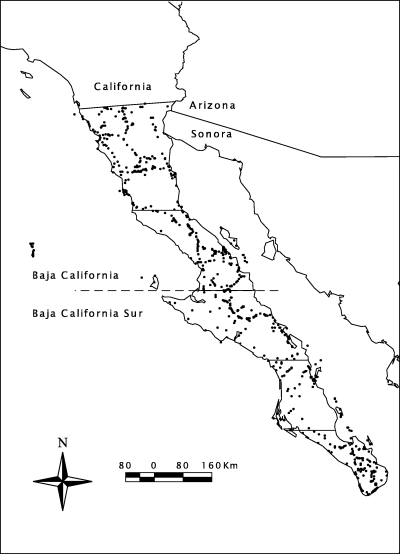

**Figure 1**

Map of the Baja California peninsula and adjacent states. The horizontal lines represent the divisions for the five latitudinal blocks. The dots represent collecting localities for specimens examined in this study; dots that appear to be in the water are on unshown islands, e.g. dots at the far left‐centre of the map represent Isla Guadalupe. The extended dashed line is the border between BCand BCS.

We used our data base of specimen records to evaluate the completeness of sampling by plotting a species accumulation curve. We then used the data base to estimate the total number of ant species in Baja California (see below). Both sets of curves were calculated using the program EstimateS (Colwell, 1997); sample order was randomized and curves were smoothed by performing 100 iterations. Prior to analysis, we edited the data base to omit redundant series. Thus, multiple nest series or multiple collections of a species from lights or pitfall traps by one collector (at the same site on the same trip) were collapsed to one series. We also deleted records for non‐native species, and added one record for each of the four species that were not examined in museum collections, but are known from literature records that we judge reliable [*Leptothorax peninsularis* (Wheeler, 1934), *Stenamma snellingi* (Smith, 1957), *Stenamma heathi* (Snelling, 1973), and *Myrmecocystus tenuinodis* (Snelling & George, 1979)]. The final data set consisted of 2101 records.

Species that appear to be peninsular endemics are noted, as well as those with restricted peninsular distributions. In particular, we note species that are essentially restricted to the relatively mesic California Floristic Province of north‐western Baja California (see above); this province extends south to *c.* 30° N. We include Isla Guadalupe (28°45′ N) in the California Floristic Province because its climate and vegetation more closely resemble mesic coastal habitats to the north. We also list extralimital distributions for each species in the adjacent states of California, Arizona, and Sonora, Mexico, based on museum specimens, literature and other data compiled by the authors.

## Results

Table 1. Summary table showing number of native ant species, by subfamily, within Baja California (BC), Baja California Sur (BCS), and summed across both states (BC and BCS). Number of species apparently endemic to each state and for the entire peninsula follows in parentheses. Species are listed by state in Appendix 1

| Number of species by subfamily | BC | BCS | BC & BCS | Additional non‐native species |
| --- | --- | --- | --- | --- |
| Cerapachyinae | 1 | 1 | 1 |  |
| Dolichoderinae | 11 (1) | 7 | 11 (4) | *Linepithema humile* (BC) |
| Ecitoninae | 7 | 6 | 8 |  |
| Formicinae | 55 (8) | 17 (3) | 60 (13) | *Anoplolepis gracilipes* (BCS); *Paratrechina longicornis* (BC, BCS) |
| Myrmicinae | 72 (4) | 50 (12) | 85 (29) | *Cardiocondyla ectopia* (BC); *Monomorium pharaonis* (BC) |
| Ponerinae | 3 | 3 | 3 (1) | *Hypoponera punctatissima* (BC, BCS) |
| Pseudomyrmecinae | 2 | 2 | 2 |  |
| Total | 151 (13) | 86 (15) | 170 (47) | Plus six non‐native species |

Table Appendix1. Ant species recorded from the states of Baja California (BC) and Baja California Sur (BCS), in the Baja California peninsula of Mexico. Species are listed alphabetically by subfamily and genus within a subfamily; taxonomy, including the authors of species names, follows Bolton (1995)

| Species<sup>a</sup> | BC | BCS | Adjacent regions<sup>b</sup> CA | Adjacent regions<sup>b</sup> AZ | Adjacent regions<sup>b</sup> Son. | Collection sources, literature references, and notes<sup>c</sup> |
| --- | --- | --- | --- | --- | --- | --- |
| Cerapachyinae |  |  |  |  |  |  |
| *Cerapachys* sp. cf. *augustae* | X | X | X | X | X | CDAE, UCDC. |
| Dolichoderinae |  |  |  |  |  |  |
| *Dorymyrmex bicolor* | X | X | X | X | X | CASC, CDAE, LACM, RAJC, UCDC. Bernstein (1979), as *Conomyrma bicolor* |
| *Dorymyrex insanus* | X | X | X | X | X | CDAE, LACM, RAJC, UCDC. Bernstein (1979), Blom & Clark (1980), as *Conomyrma insana* in both |
| *Dorymyrex* sp. BCA‐1 (E) | X | X |  |  |  | CDAE, LACM, RAJC, UCDC. Possible Baja California endemic. Related populations in CA, AZ, and Son |
| *Dorymyrmex* sp. BCA‐2 (E) | X | X |  |  |  | RAJC, UCDC. Apparent Baja California endemic |
| *Forelius mccooki* | X | X | X | X | X | CDAE, LACM, RAJC, UCDC. Cuezzo (2000) |
| *Forelius pruinosus* | X | X | X | X | X | CDAE, LACM, RAJC, UCDC. Bernstein (1979), Blom & Clark (1980), as *Iridomyrmex pruinosus*(*um*) *analis* in both; Cuezzo (2000, as *F. analis*) |
| *Forelius* sp. BCA‐1 (E) | X |  |  |  |  | UCDC. Apparent BC endemic |
| *Forelius* sp. BCA‐2 (E) | X | X |  |  |  | RAJC, UCDC. Apparent Baja California endemic |
| **Linepithema humile* (N) | X |  | X | X |  | LACM |
| **Liometopum luctuosum* | X |  | X | X |  | LACM, RAJC, UCDC |
| **Liometopum occidentale* | X |  | X |  |  | RAJC, UCDC. Snelling & George (1979) |
| **Tapinoma sessile* | X |  | X | X |  | CASC, CDAE, LACM, RAJC, UCDC. Snelling & George (1979) |
| Ecitoninae |  |  |  |  |  |  |
| **Neivamyrmex californicus* | X |  | X |  |  | RAJC, UCDC. Ward (1999) |
| *Neivamyrmex leonardi* | X | X | X | X | X | CASC, LACM, UCDC. Mann (1926, as *Eciton peninsulare*); Borgmeier (1955), Snelling & George (1979), Watkins (1982) |
| *Neivamyrmex minor* | X | X | X | X |  | CASC, LACM, UCDC. Smith (1942, as *Eciton minus*); Borgmeier (1955), Snelling & George (1979), Watkins (1982). Probably the male of *N. leonardi* |
| *Neivamyrmex mojave* |  | X | X |  |  | LACM. Possibly the male of *N. nyensis* |
| *Neivamyrmex nigrescens* | X | X | X | X | X | CASC, CDAE, LACM, RAJC, UCDC. Watkins (1982), Coria‐Benet *et al*. (1993), Ward (1999) |
| *Neivamyrmex nyensis* | X | X | X |  |  | LACM, UCDC |
| *Neivamyrmex opacithorax* | X | X | X | X | X | LACM, UCDC. Pergande (1896, as *Eciton californicum* ssp. *opacithorax*); Borgmeier (1955), Watkins (1982) |
| *Neivamyrmex swainsonii* | X |  | X | X | X | CDAE, LACM. Watkins (1982) |
| Formicinae |  |  |  |  |  |  |
| **Acanthomyops californicus* | X |  | X |  |  | LACM, RAJC, UCDC |
| *Anoplolepis gracilipes* (N) |  | X |  |  |  | CASC. Pergande (1894, as *Plagiolepis longipes*) |
| *Brachymyrmex depilis* | X | X | X | X | X | CASC, UCDC. Blom & Clark (1980) |
| **Camponotus anthrax* | X |  | X |  |  | CASC, LACM, RAJC, UCDC. Snelling (1988) |
| *Camponotus clarithorax* | X | X | X |  |  | CASC, CDAE, RAJC, UCDC. Snelling (1988) |

[output cut: 158 more lines]

- <sup>a,</sup>* Species mostly restricted to the California Floristic Province; (E), species currently treated as endemic to Baja California; (N), non‐native species.
- b Adjacent regions are: CA=California; AZ=Arizona; Son.=Sonora, Mexico.
- <sup>c</sup> CASC, California Academy of Sciences; CDAE, California Department of Food and Agriculture, Sacramento; LACM, Natural History Museum of Los Angeles County; RAJC, Robert A. Johnson collection, Tempe, Arizona; UCDC, Bohart Museum of Entomology, University of California, Davis; USNM, National Museum of Natural History, Smithsonian Institution, Washington, DC. For literature references, the species name used in the publication is listed when it differs from current nomenclature (except for spelling variations of specific epithets). For endemic status, species for which we have high confidence are listed as endemic, while poorly known species or those with questionable taxonomic status are listed as ‘apparent’ or ‘possible’ endemics.

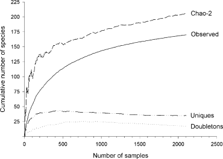

**Figure 2**

Accumulation curves for observed and estimated ant species richness in Baja California, Mexico, based on examination of 2101 series from museum collections (see text). Observed: observed species richness. Chao‐2: nonparametric estimator of species richness. Uniques: number of species known from only one collection. Doubletons: number of species known from only two collections. Data were analysed using 100 iterations of the program Estimates.

With regard to our species list, we delete two species previously recorded from the peninsula. We remove *Camponotus phytophilus* from the fauna because Wheeler's (1934) record of this species from Magdalena Bay, BCS, is based on misidentification of *Camponotus mina* (specimens in CASC, examined by PSW). Also deleted from the Baja California list is *Pheidole cockerelli*. Creighton's (1958) record of this species from the Cape Region is due to misidentification of the type specimens of *Ph. vaslitii*, which is now known to be a junior synonym of *Ph. hyatti* (Ward, 2000).

The majority of native ant species in Baja California probably originated in neighbouring areas to the north and east. Approximately one‐third of the species (53 of 170) and 24% of the genera (eight of thirty‐three) are restricted to the California Floristic Province, and thus are largely derived from coastal and mild inland habitats to the north. Genera restricted to this area of Baja California include *Acanthomyops*, *Lasius*, *Liometopum*, *Myrmecina*, *Myrmica*, *Polyergus*, *Stenamma* and *Tapinoma*. The non‐native Argentine ant, *Linepithema humile*, and *Cardiocondyla ectopia* are also restricted to this province. Additionally, the Sonoran and Chihuahuan Deserts, including chaparral and oak woodland habitats, appear to be the source for about one‐half of the species. Tropical faunal components are poorly represented. *Leptogenys peninsularis*, *Leptothorax* sp. BCA‐4, and *Crematogaster rossi* might be considered in this category. The absence of other tropical ant taxa, such as *Pachycondyla*, *Azteca* and *Cephalotes* (= *Zacryptocerus*), is notable.

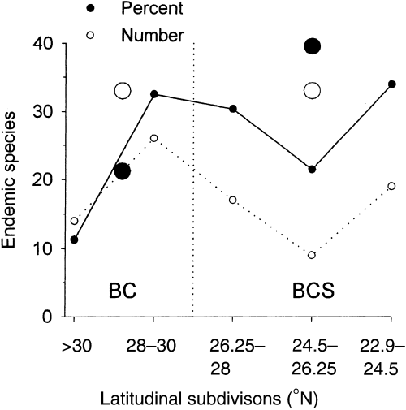

**Figure 3**

Number of endemic ant species and percent of total ant species that are endemic in the five latitudinal subdivisions (symbols and lines) and to the two states (BC and BCS) of Baja California (larger symbols). The vertical dotted line separates data for the two states; lower latitudes represent more distal portions of the peninsula.

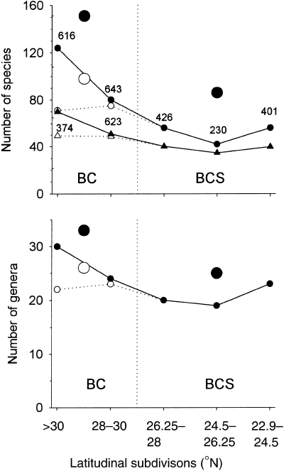

**Figure 4**

Number of ant species (top) and genera (bottom) in the five latitudinal subdivisions (symbols and lines) and in the two states (BC and BCS) of Baja California (larger symbols). Filled circles are all species/genera; open circles omit species/genera that are mostly restricted to the California Floristic Province. Filled triangles are species richness estimates using the rarefaction method for all species/genera; open triangles omit species/genera that are mostly restricted to the California Floristic Province (see text). The vertical dotted line separates data for the two states; lower latitudes represent more distal portions of the peninsula. Number of collections within each latitudinal subdivision is given above the data points in the top panel.

Nine ant species exhibit disjunct distributions, and these occur in two general patterns: peninsula disjuncts and peninsula–mainland disjuncts. Peninsula disjuncts include four species (*Camponotus clarithorax*, *Camponotus hyatti*, *Prenolepis imparis*, and *Leptothorax* sp. nr. *silvestrii*). The former three species are only recorded in the California Floristic Province of BC with disjunct populations in the Sierra de la Laguna of the Cape Region. *Leptothorax* sp. nr. *silvestrii* occurs in central peninsular areas and southern California. Peninsula–mainland disjuncts include five species (*Camponotus mina*, *Camponotus* sp. nr. *festinatus*, *Crematogaster arizonensis*, *Crematogaster rossi* and *Paratrechina bruesii*) which are only recorded from central and southern parts of the peninsula, with disjunct populations in southern Arizona and/or mainland Mexico. All five species are absent from northern peninsula areas and California.

## Species richness

The ants of Baja California consist of a diverse assemblage of species derived from adjacent coastal areas, mountains and deserts. The nearly one‐third of the species restricted to the California Floristic Province are largely derived from similar habitats in coastal range areas of southern California. A large number of desert species are shared with adjacent Sonoran Desert communities in south‐eastern California, Arizona, and mainland northern Mexico. Snelling & George (1979) and Johnson (2000b) discuss ecology, zoogeographical origin and geographical distribution for many of these species. Unlike other taxa, such as plants (Wiggins, 1980) and butterflies (Brown, 1987), ants of tropical origin are relatively scarce in Baja California; at the genus level only *Leptogenys* is arguably ‘tropical’. More extensive collecting in the Cape Region might change this picture.

Our current list of 170 ant species continues to increase, as exemplified by our adding >20% (*c.* 37) of these species during short collecting trips in the last three years. Despite these efforts, several ant species expected to occur in Baja California remain missing from our list. Genera likely to increase by at least several species include *Camponotus*, *Crematogaster*, *Leptothorax*, *Myrmecocystus*, *Pheidole*, and *Solenopsis* (*Diplorhoptrum*); genera that might be added include *Acropyga*, *Amblyopone* and *Rogeria*. Revision of difficult groups, such as *Crematogaster*, *Dorymyrmex*, *Forelius*, *Monomorium*, *Neivamyrmex* (matching worker and male castes), and *Solenopsis* (*Diplorhoptrum*) is necessary to clarify species boundaries, and will probably alter the number of species known from Baja California.

The incompleteness of our species list is also indicated by the Chao‐2 estimator of 206 species, which suggests that more than thirty‐five species are yet to be found. This estimator has continued to rise following recent collecting trips, and thus likely represents a lower bound for total species richness (see also Longino *et al*., 2001). Other indicators ofan incomplete species list include lack of convergence between the observed and estimated species richness curves (Fig. 2), and a relatively constant number of uniques and duplicates with increased sampling (see Fisher, 1999; Longino *et al*., 2001). Additionally, several cryptic species likely remain undiscovered because collecting techniques have been mostly limited to nest collections and pitfall traps. Extraction of ants from sifted leaf litter using Winkler traps has seen very limited use in Baja California. This technique has proved to be very productive when conducting systematic inventories of ants (Fisher, 1999; Agosti *et al*., 2000; Longino *et al*., 2001) and can be expected to reveal additional taxa in Baja California, at least from mesic habitats. Thus, additional collections are necessary to more accurately define the ant fauna of Baja California and to resolve the questionable taxonomic status of several species, especially those with similar forms in adjacent states. Locations in which we expect additional collecting will prove most productive include the Sierra San Pedro Mártir in the north and Sierra de la Laguna in the Cape Region. With regard to extralimital distributions, we consider our Arizona and California records relatively complete, although additional species continue to be found. In comparison, the ant fauna of Sonora is poorly known and numerous species will be added as this region is explored.

Our estimate of slightly over 200 ant species for Baja California also appears reasonable in light of species richness data from adjacent areas (California, 242 species; Arizona, 290 species), and given that the peninsula has topographic diversity comparable to that of Arizona and California (Table 2). We expect the number of species to be somewhat lower in Baja California than in these adjacent states, however, because Baja California is smaller in area and is more isolated from mainland source pools.

Table 2. Numbers of native genera and species (in parentheses) of ants known from the Baja California peninsula, Mexico, and adjacent states; Sonora, Mexico, is excluded because the ant fauna remains mostly unknown. Totals for California and Arizona are based on unpublished lists by P.S. Ward and S.P. Cover & R.A. Johnson, respectively. Area and range in elevation are included to allow comparison of species–area relationships and habitat diversity indices, respectively, among these states

| Location | Ants genera (species) | Area (km<sup>2</sup>) | Range in elevation (m) |
| --- | --- | --- | --- |
| Baja California | 33 (170) | 143,396 | 0–3096 |
| BC<sup>a</sup> | 33 (151) | 69,921 | 0–3096 |
| BCS<sup>a</sup> | 24 (86) | 73,475 | 0–2000 |
| California | 38 (242) | 411,471 | −86–4600 |
| Arizona | 40 (290) | 295,274 | 43–3851 |

- a BC and BCS are the states of Baja California and Baja California Sur, respectively.

## Biogeography and endemism

As with plants and other animal taxa (Wiggins, 1980; Case & Cody, 1983), several ant species appear endemic to offshore islands. Two species, *Camponotus keiferi* and *Camponotus maccooki*, are endemic to Isla Guadalupe, while *A. patruelis* is only known from Isla Guadalupe and the Channel Islands off the coast of California. Four other species, *Forelius* sp. BCA‐1, *Leptothorax* sp. BCA‐6, *Leptothorax* sp. BCA‐7, and *Pheidole* sp. BCA‐5 are apparently endemic to islands in the Sea of Cortez, although additional collecting might reveal their presence on the Baja California mainland. Lastly, eleven of the species that we list as endemics have uncertain taxonomic status at this time, i.e. they may be conspecific with species in adjacent states or they have related forms that occur in those areas (Appendix 1). Additional collections and systematic studies are needed to clarify the identity of these species. To the extent that they prove to be allopatric isolates of similar mainland forms, resolution of species status may be somewhat arbitrary.

The peninsular effect has been questioned as a general phenomenon because other biogeographical factors (e.g. ecological barriers, habitat diversity) may explain patterns of species richness as well as does the geographical configuration of the peninsula (Busack & Hedges, 1984; Brown, 1987). This hypothesis has been tested several times in Baja California, where it has been supported (Taylor & Regal, 1978; for lizards, breeding birds, mammals, bats, heteromyid rodents) and refuted (Seib, 1980, for lizards and snakes; Lawlor, 1983, for mammals and bats; Brown, 1987, for butterflies; Due & Polis, 1986, for scorpions; Ayala *et al*., 1993, for bees; Wiggins, 1999, for breeding birds).Our results, using the full complement of ant species, support the peninsular effect at both the genus and species levels when a comparison is made between the two states. However, when minimizing habitat effects by removing those species confined to the California Floristic Province in north‐western BC, the peninsular effect becomes weak at the species level (ninety‐eight in BC vs. eighty‐six in BCS) and disappears at the genus level (twenty‐five in BC vs. twenty‐four in BCS). Note, however, that this analysis also decreases the area of BC by about one‐third (the two states otherwise have similar areas). Our analysis across the five latitudinal blocks provides poor support for the peninsular effect because a decline in species number in central portions of the peninsula is followed by an upturn in species number in the Cape Region.

Some of the above tests of the peninsular effect have been criticized for using inadequate data sets. For example, Taylor & Regal (1978) overlooked several bat species that occur in the Cape Region; including these species changed the pattern from one that supported the peninsular effect to a reversed peninsular effect with more species in the Cape Region than in northern areas (see Lawlor, 1983). We acknowledge that our data set is far from complete, but note that our results are based on a relatively dense and even distribution of collecting localities across the peninsula (Fig. 1). Our test of the peninsular effect uses a similar number of collections to compare species richness between the two states (1259 in BC vs. 1057 in BCS), but the number of collections differs more markedly across the five latitudinal blocks (see Fig. 4). Rarefaction provided estimates of species number that minimized effects related to sampling effort across these blocks, and yielded a pattern of species number that coincided with our observed number of species, i.e. a decreased number of species in central portions of the peninsula followed by an upturn in the Cape Region (Fig. 4).

We believe that the upturn in number of ant species in the Cape Region is a real phenomenon, with supporting data coming from similar patterns for better known groups such as birds, bats, butterflies, and bees (Lawlor, 1983; Brown, 1987; Ayala *et al*., 1993; Wiggins, 1999). This upturn isbest explained by high topographic relief and hence increased habitat diversity in the Cape Region compared with central portions of the peninsula. Breeding birds provide the best support for the habitat diversity hypothesis because the increased number in the Cape Region is caused by addition of high elevation species, which comprise a group that is lacking in central portions of the peninsula (Wiggins, 1999). Likewise, the upturn in number of ant species is best explained by increased habitat diversity, especially given that most ant species also display strong elevational affinities. Thus, habitat diversity, especially that related to topographic relief, appears to be the most important factoraffecting the gradient of ant species richness in Baja California.

More refined analyses of other taxa have also revealed a north to south gradation of faunal components in Baja California, a pattern that decreases the importance of the recolonization–extinction model upon which the peninsular effect is based (see Taylor & Regal, 1978). Bats (Lawlor, 1983), butterflies (Brown, 1987), and lizards and snakes (Seib, 1980) consist of Nearctic and Neotropical components that display inverse distribution patterns; Nearctic species are common in northern areas and become rare further south, whereas Neotropical species are most common in the Cape Region and become increasingly rare further north. In contrast, tropical faunal components are mostly lacking in the ants and the increased species diversity in the Cape Region appears to be at least partly attributable to a greater number of mesophilic species. Some of these are disjuncts, occurring also at the base of the peninsula or in Arizona; others are local endemics.

The disjunct distribution pattern exhibited by several ant species in Baja California is common to other taxa including plants (Wiggins, 1980; Turner *et al*., 1995), reptiles (Murphy, 1983) and butterflies (Brown, 1987). Apparent disjunct distributions in these ants may result from three causes: (1) sampling artefact, i.e. lack of collections to adequately document the distribution, (2) dispersal colonization from the mainland, and (3) range contraction in species that were previously more geographically widespread, but have since gone extinct in portions of their range. With regard to sampling effort, collections are obviously lacking from some parts of the peninsula (Fig. 1), and the known geographical ranges of many species will undoubtedly expand. Long‐distance dispersal apparently has occurred in Baja California plants (Turner *et al*., 1995) and butterflies (Brown, 1987), but its role in ants is unclear. Mating flights, although triggered by rains in most desert ants, are generally short‐lived and restricted to subsequent periods of better weather that would be unfavourable to *trans*‐gulf dispersal. From this perspective, one might favour the hypothesis of range contraction, i.e. that some peninsula disjuncts were widespread historically, but became extinct in the central peninsula as a result of increasing aridity over the last 10,000–20,000 years (Axelrod, 1979). Southern populations of several mesophilic species persist in the wetter climates of the Sierra de la Laguna of the Cape Region. Some peninsula–mainland disjuncts may represent older relict populations of species that were present prior to gulf‐floor spreading and formation ofthe peninsula in the late Miocene. For example, both *Paratrechina bruesii* and *Camponotus* sp. nr. *festinatus* are upland species known only from the Cape Region, with the closest known populations in the mountains of southern Arizona and northern Mexico. Such peninsula–mainland disjuncts are strikingly absent from the northern peninsular areas and southern California.

## Acknowledgments

This paper grew out of a symposium on the entomofauna of Baja California that was organized by William H. Clark and Richard L. Westcott, and held during the 1998 annual meeting of the Entomological Society of America. We thank Stefan P. Cover, Brian L. Fisher, John T. Longino, and Roy R. Snelling for critical comments that improved the manuscript; John T. Longino also provided valuable insight on methods to estimate species richness. We also thank the following curators for facilitating study of material in their collections: Wojciech Pulawski (CASC), John Sorensen (CDAE), Roy Snelling (LACM) and Ted Schultz (USNM). Additional material was provided by Rolf Aalbu, April Boulton, Ted Case, and Andy Suarez. PSW acknowledges support of the University of California (Davis) and the National Science Foundation for his work on antsystematics.

## Biosketches

**Dr Robert Johnson** is Adjunct Faculty at Arizona State University. He has a wide range of interests in ants, with his research focusing on evolutionary ecology, community structure, biogeography and nest founding strategies of seed‐harvester ants.

**Dr Philip Ward** is an ant systematist and Professor of Entomology at the University of California, Davis. His research is concerned with the species‐level taxonomy, phylogeny and biogeography of ants, with a particular emphasis on the Neotropical fauna and on the subfamily Pseudomyrmecinae.